# PUBH 7462 Week 13 activity: Parallel bootstrapping

Author

Eric Lock

## Objective

The goal of this lab is to move beyond serial execution. You will implement a computationally intensive bootstrap simulation and compare the performance of standard R loops against a parallelized backend.

## The Task: Bootstrapping a Non-linear Model

We will estimate the sampling distribution of parameters for a non-linear decay model:
$$y = a \cdot e^{-bx} + \epsilon$$

Because Non-linear Least Squares (NLS) requires an iterative numerical solution for every resample, it is significantly more demanding than linear regression, making it an ideal candidate for parallelization.

### 1. The Setup

First, generate a large synthetic dataset ($n=10000$) and fit an initial model:

```r
library(stats)
set.seed(123)
n <- 10000
x <- runif(n, 0, 10)
y <- 5 * exp(-0.5 * x) + rnorm(n, sd = 0.2)
df <- data.frame(x, y)

# Fit to simulated data, using starting values:
start_vals <- list(a = 1, b = 1)
fit <- nls(y ~ a * exp(-b * x), data = df, start = start_vals)
a.est=summary(fit)$coefficients[1,1] #estimate for a
b.est=summary(fit)$coefficients[2,1] #estimate for b
```

### 2. Serial Execution

Perform $B = 1,000$ bootstrap resamples using a standard `for` loop or `lapply`. Use `system.time()` to record how long it takes.

*Tip: Use `tryCatch()` inside your loop, as NLS may occasionally fail to converge on certain resamples.*

### 3. Parallel Execution

Refactor your code to run in parallel using the `doParallel` and `foreach` packages.

1. **Detect and Register:** Use `detectCores()` to see what you have, then register the backend. I suggest using one less than your total number of cores, just to not overload your computer.

   ```r
   library(doParallel)
   n_cores <- parallel::detectCores()
   n_cores
   ```

   ```
   [1] 10
   ```

   ```r
   registerDoParallel(cores = n_cores-1)
   ```

2. **Foreach Implementation:** Use `foreach` with the `%dopar%` operator.
   - Use `.combine = 'rbind'` to return a data frame of the estimated a and b for each bootstrap sample.
   - Use `.packages = 'stats'` to ensure `nls` is available to the workers.
3. **Cleanup:** When finished, shut down the workers:

   ```r
   stopImplicitCluster()
   ```

### 4. Plot the bootstrap results

Make a simple histogram of the bootstrapped estimates for a and b, to check the results. They should look something like this:

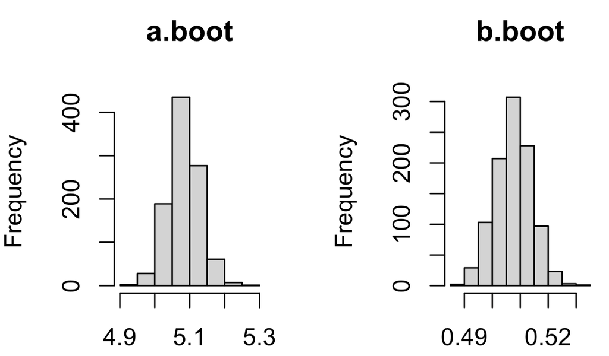

### 5. Compare computing time and experiment

Was the parallel approach substantially faster than the serial approach? Try rerunning both approaches with different sample sizes ‘n’. You might find that when n is smaller (e.g., n=100) the serial approach is actually faster, because each step is quick and the estimation time is dominated by the overhead of parallelization rather than the computation itself. When n is very large (e.g., n=30000) the estimation can take substantial time, and you are likely to see more benefits of parallelization.

Upload your R script on Canvas to receive credit for this activity.